# Assignment 4

In this assignment, you'll combine the assignment 3 data set with nutrition data from the [USDA Food Composition Databases](https://ndb.nal.usda.gov/ndb/search/list). The CSV file `fresh.csv` contains the fresh fruits and vegetables data you extracted in assignment 3.

The USDA Food Composition Databases have a [documented](https://ndb.nal.usda.gov/ndb/doc/index) web API that returns data in JSON format . You need a key in order to use the API. Only 1000 requests are allowed per hour, so it would be a good idea to use [caching](https://pypi.python.org/pypi/requests-cache).

[Sign up for an API key here](https://api.data.gov/signup/). The key will work with any Data.gov API. You may need the key again later in the quarter, so make sure you save it.

These modules may be useful:

- [requests](http://docs.python-requests.org/en/master/user/quickstart/)
- [requests_cache](https://pypi.python.org/pypi/requests-cache)
- [urlparse](https://docs.python.org/2/library/urlparse.html)
- [pandas](http://pandas.pydata.org/pandas-docs/stable/)

```python
import requests
import requests_cache
import urlparse
import pandas as pd
from matplotlib import pyplot as plt
import matplotlib
requests_cache.install_cache("cache")
```

**Exercise 1.1.** Read the [search request documentation](https://ndb.nal.usda.gov/ndb/doc/apilist/API-SEARCH.md), then write a function called `ndb_search()` that makes a search request. The function should accept the search term as an argument. The function should return the search result items as a list (for 0 items, return an empty list).

Note that the search url is: `https://api.nal.usda.gov/ndb/search`

As an example, a search for `"quail eggs"` should return this list:

```
[{u'ds': u'BL',
  u'group': u'Branded Food Products Database',
  u'name': u'CHAOKOH, QUAIL EGG IN BRINE, UPC: 044738074186',
  u'ndbno': u'45094707',
  u'offset': 0},
 {u'ds': u'BL',
  u'group': u'Branded Food Products Database',
  u'name': u'L&W, QUAIL EGGS, UPC: 024072000256',
  u'ndbno': u'45094890',
  u'offset': 1},
 {u'ds': u'BL',
  u'group': u'Branded Food Products Database',
  u'name': u'BUDDHA, QUAIL EGGS IN BRINE, UPC: 761934535098',
  u'ndbno': u'45099560',
  u'offset': 2},
 {u'ds': u'BL',
  u'group': u'Branded Food Products Database',
  u'name': u'GRAN SABANA, QUAIL EGGS, UPC: 819140010103',
  u'ndbno': u'45169279',
  u'offset': 3},
 {u'ds': u'BL',
  u'group': u'Branded Food Products Database',
  u'name': u"D'ARTAGNAN, QUAIL EGGS, UPC: 736622102630",
  u'ndbno': u'45178254',
  u'offset': 4},
 {u'ds': u'SR',
  u'group': u'Dairy and Egg Products',
  u'name': u'Egg, quail, whole, fresh, raw',
  u'ndbno': u'01140',
  u'offset': 5}]
```

As usual, make sure you document and test your function.

```python
def ndb_search(search_term):
    """
    This function takes an argument that specifies the term to be used in
    the search request to the USDA API. A json list is returned with all the
    relevant food items containing the search term. If no items are found, an
    empty list is returned.
    Input: search term(string)
    Output: a list of all relevant food items with their corresponding info.
    """
    url = 'https://api.nal.usda.gov/ndb/search' #given search url
    #dict of parameters to be passed in requests.get()
    pars = {'q': search_term, 'api_key': key,'format':'json'}
    res = requests.get(url, params = pars) #requesting
    res_json = res.json() #parse JSON
    if 'errors' in res_json.keys(): #checking for no item found
        res_json= {u'list':{u'item':[]}} #set to empty list

    return res_json[u'list'][u'item'] #return just list of items

#key = 'apikey'
ndb_search('quail eggs')
```

```
[{u'ds': u'BL',
  u'group': u'Branded Food Products Database',
  u'name': u'CHAOKOH, QUAIL EGG IN BRINE, UPC: 044738074186',
  u'ndbno': u'45094707',
  u'offset': 0},
 {u'ds': u'BL',
  u'group': u'Branded Food Products Database',
  u'name': u'L&W, QUAIL EGGS, UPC: 024072000256',
  u'ndbno': u'45094890',
  u'offset': 1},
 {u'ds': u'BL',
  u'group': u'Branded Food Products Database',
  u'name': u'BUDDHA, QUAIL EGGS IN BRINE, UPC: 761934535098',
  u'ndbno': u'45099560',
  u'offset': 2},
 {u'ds': u'BL',
  u'group': u'Branded Food Products Database',
  u'name': u'GRAN SABANA, QUAIL EGGS, UPC: 819140010103',
  u'ndbno': u'45169279',
  u'offset': 3},
 {u'ds': u'BL',
  u'group': u'Branded Food Products Database',
  u'name': u"D'ARTAGNAN, QUAIL EGGS, UPC: 736622102630",
  u'ndbno': u'45178254',
  u'offset': 4},
 {u'ds': u'SR',
  u'group': u'Dairy and Egg Products',
  u'name': u'Egg, quail, whole, fresh, raw',
  u'ndbno': u'01140',
  u'offset': 5}]
```

**Exercise 1.2.** Use your search function to get NDB numbers for the foods in the `fresh.csv` file. It's okay if you don't get an NDB number for every food, but try to come up with a strategy that gets most of them. Discuss your strategy in a short paragraph.

Hints:

- The foods are all raw and unbranded.
- You can test search terms with the [online search page](https://ndb.nal.usda.gov/ndb/search/list).
- You can convert the output of `ndb_search()` to a data frame with `pd.DataFrame()`.
- The string methods for [Python](https://docs.python.org/2/library/stdtypes.html#string-methods) and [Pandas](http://pandas.pydata.org/pandas-docs/stable/text.html#method-summary) are useful here. It's okay if you use *simple* regular expressions in the Pandas methods, although this exercise can be solved without them.
- You can merge data frames that have a column in common with `pd.merge()`.

```python
fresh = pd.read_csv('fresh.csv', header=0)
search_df = fresh['food'].str.replace('_', ' ') #make into valid search terms

def get_ndbno(items):
    """
    This function takes an argument for the food items for which the ndbno will be obtained.
    A list, pandas Series, or DataFrame (1 column) of valid search terms is taken as the
    argument. A dataframe will be returned, constructed from appending the ndb numbers
    to the appropriate items.
    Input: list, pandas Series, or 1 col. DataFrame
    Output: pandas DataFrame
    Example: get_ndbno(['plum','watermelon']) gives ndbno for plum and watermelon as a DataFrame
    """
    items = pd.DataFrame(items, columns = ['food']) #if arg. a list/Series
    ndbno_list = [] #initialize empty list to store ndb numbers

    for row in items.itertuples(): #iterate through each rows
        #search with addition of raw to narrow down
        if row[1] == 'kiwi': #check special case 'kiwi'
            res_df = ndb_search(row[1] + 'fruit' + ' raw')
        else: res_df = ndb_search(row[1] + ' raw')
        res_df = pd.DataFrame(res_df) #turn to DF
        #filter out branded by searching Standard Ref. database only
        res_df = res_df.loc[res_df['ds'] == 'SR']
        #check for duplicate to grab different ndb num. Append nums. to list
        if items.duplicated('food')[row[0]] == True:
            ndbno_list.append(res_df.iloc[1]['ndbno'])
        else: ndbno_list.append(res_df.iloc[0]['ndbno'])
#         print ndbno_list[row[0]], row[1] #Used during testing to pinpoint error culprit
    final_df = pd.concat([items, pd.DataFrame(ndbno_list, columns = ['ndbno'])], axis=1)
    return final_df #final concatinated dataframe

# get_ndbno(['plum','watermelon'])
get_ndbno(['plum','watermelon'])
```

|  | food | ndbno |
| --- | --- | --- |
| 0 | plum | 09279 |
| 1 | watermelon | 09326 |

The general strategy for this excercise was to be meticulous and fully utilize the manual checking feature. Trial and error also played a role and having a print call after every item searched is beneficial in catching for which item problems occurred. Then appropriate checks are put in place to grab the most ndb numbers as possible. A unique ndb number was found for every item given in the fresh.csv file.

# res_df = res_df.loc[res_df['group'].str.contains(row[2],case=False)]

# res_df = res_df.loc[res_df['name'].str.contains(row[1].capitalize())]

The above two checks proved to be too strict and prompted some no results found errors. They were taken out in the end. The commented out print statement was used as a trial and error strategy to pinpoint where things break down. Also, cabbage is a problem because of the swamp-cabbage result. The second statement above would filter it out but as mentioned, proved problematic for other items.

**Exercise 1.3.** Read the [food reports V2 documentation](https://ndb.nal.usda.gov/ndb/doc/apilist/API-FOOD-REPORTV2.md), then write a function called `ndb_report()` that requests a *basic* food report. The function should accept the NDB number as an argument and return the list of nutrients for the food.

Note that the report url is: `https://api.nal.usda.gov/ndb/V2/reports`

For example, for `"09279"` (raw plums) the first element of the returned list should be:

```
{u'group': u'Proximates',
 u'measures': [{u'eqv': 165.0,
   u'eunit': u'g',
   u'label': u'cup, sliced',
   u'qty': 1.0,
   u'value': u'143.93'},
  {u'eqv': 66.0,
   u'eunit': u'g',
   u'label': u'fruit (2-1/8" dia)',
   u'qty': 1.0,
   u'value': u'57.57'},
  {u'eqv': 151.0,
   u'eunit': u'g',
   u'label': u'NLEA serving',
   u'qty': 1.0,
   u'value': u'131.72'}],
 u'name': u'Water',
 u'nutrient_id': u'255',
 u'unit': u'g',
 u'value': u'87.23'}
```

Be sure to document and test your function.

```python
def ndb_report(ndbno):
    """
    This function requests and returns a basic nutrition report from the USDA database
    for the ndb number which is taken as the argument (a string). Overall, same procedure
    as for the ndb_search() function.
    Input: a string of the five-digit ndbno
    Output: List of nutrients for the requested food item
    """
    #mostly same process as ndb_search function
    ndbno = str(ndbno)
    url = 'https://api.nal.usda.gov/ndb/V2/reports'
    pars = {'ndbno': ndbno, 'api_key': key, 'format': 'json'}
    req = requests.get(url, params = pars)
    res_json = req.json()
    if res_json['notfound'] == 1:
        print res_json[u'foods'][0]
    else: return res_json[u'foods'][0][u'food']['nutrients']

#key = 'api_key'
ndb_report('09279')[0]
```

```
{u'group': u'Proximates',
 u'measures': [{u'eqv': 165.0,
   u'eunit': u'g',
   u'label': u'cup, sliced',
   u'qty': 1.0,
   u'value': u'143.93'},
  {u'eqv': 66.0,
   u'eunit': u'g',
   u'label': u'fruit (2-1/8" dia)',
   u'qty': 1.0,
   u'value': u'57.57'},
  {u'eqv': 151.0,
   u'eunit': u'g',
   u'label': u'NLEA serving',
   u'qty': 1.0,
   u'value': u'131.72'}],
 u'name': u'Water',
 u'nutrient_id': u'255',
 u'unit': u'g',
 u'value': u'87.23'}
```

**Exercise 1.4.** Which foods provide the best combination of price, yield, and nutrition? You can use kilocalories as a measure of "nutrition" here, but more a detailed analysis is better. Use plots to support your analysis.

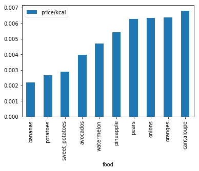

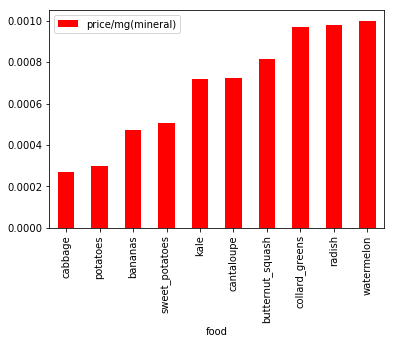

```python
def nutri_val(ndbno):
    """
    This function takes in an ndb number and returns a dictionary comprising of
    the energy value and total mineral in miligrams for that food item
    Input: string, the ndbno for the item
    Output: Dictionary, energy and mineral values
    """
    nutri = ndb_report(ndbno) #get the report
    #grab the value of nutrien report corresponding to energy
    energy = float([e for e in nutri if e['name'] == 'Energy'][0]['value'])
    #grab the mineral values for all types
    mineral = [e for e in nutri if e['group'] == 'Minerals']
    #sum up all the mineral contents (miligrams)
    tot_min = sum(float(val['value']) for val in mineral)

    return {'energy':energy, 'mineral':tot_min} #return dict

fresh = pd.read_csv('fresh.csv', header=0)
fresh_nutri = [] #initialize list to store nutrients
for e in get_ndbno(search_df)['ndbno']: #loops through all food in fresh
    fresh_nutri.append(nutri_val(e)) #uses the ndbno from get_ndbno function
fresh_nutri = pd.DataFrame(fresh_nutri) #turn into pd df
#Price converted to price/gram, then divide by yield and times 100
#Price per 100g of yield
price_per_100g_yield = (fresh['price_per_lb'] / 453.592 / fresh['yield']) * 100
price = pd.DataFrame(price_per_100g_yield, columns = ['price'])
comp_df = pd.concat([price, fresh_nutri], axis = 1) #combine for easy access
comp_df = pd.concat([comp_df, pd.DataFrame(fresh['food'],columns = ['food'])], axis = 1)
comp_df['price/kcal'] = comp_df.price / comp_df.energy #add column for price per unit kcal
comp_df['price/mg(mineral)'] = comp_df.price / comp_df.mineral #col. for price per unit mineral

#sorting by price for energy and mineral
val_by_energy = comp_df.sort_values(by ='price/kcal')[['price/kcal','food']]
val_by_mineral = comp_df.sort_values(by = 'price/mg(mineral)')[['price/mg(mineral)', 'food']]
#top 10 in terms of lowest price per unit measurement
top10_by_energy = val_by_energy.head(10)
top10_by_min = val_by_mineral.head(10)
#plot the food and their corresponding price/unit measurement
top10_by_energy.plot(x = 'food', y = 'price/kcal', kind = 'bar')
top10_by_min.plot(x = 'food', y = 'price/mg(mineral)', kind = 'bar', color = 'r')
plt.show()
```